# Linux Basics

Biostat 203B

Dr. Hua Zhou @ UCLA

Jan 7, 2020

## Why Linux

Linux is *the* most common platform for scientific computing and deployment of data science tools.

- Open source and community support.
- Things break; when they break using Linux, it’s easy to fix.
- Scalability: portable devices (Android, iOS), laptops, servers, clusters, and super computers.
  - E.g. UCLA Hoffmann2 cluster runs on Linux; most machines in cloud (AWS, Azure, GCP) run on Linux.
- Cost: it’s free!

## [Distributions of Linux](http://upload.wikimedia.org/wikipedia/commons/1/1b/Linux_Distribution_Timeline.svg)

- Debian/Ubuntu is a popular choice for personal computers.
- RHEL/CentOS is popular on servers.
- The teaching server for this class runs CentOS 7.
- MacOS was originally derived from Unix/Linux (Darwin kernel). It is POSIX compliant. Most shell commands we review here apply to MacOS terminal as well. Windows/DOS, unfortunately, is a totally different breed.
- Show distribution/version on Linux:

  ```bash
  cat /etc/*-release
  ```

  ```
  CentOS Linux release 7.7.1908 (Core)
  NAME="CentOS Linux"
  VERSION="7 (Core)"
  ID="centos"
  ID_LIKE="rhel fedora"
  VERSION_ID="7"
  PRETTY_NAME="CentOS Linux 7 (Core)"
  ANSI_COLOR="0;31"
  CPE_NAME="cpe:/o:centos:centos:7"
  HOME_URL="https://www.centos.org/"
  BUG_REPORT_URL="https://bugs.centos.org/"

  CENTOS_MANTISBT_PROJECT="CentOS-7"
  CENTOS_MANTISBT_PROJECT_VERSION="7"
  REDHAT_SUPPORT_PRODUCT="centos"
  REDHAT_SUPPORT_PRODUCT_VERSION="7"

  CentOS Linux release 7.7.1908 (Core)
  CentOS Linux release 7.7.1908 (Core)
  ```

- Show distribution/version on MacOS:

  ```bash
  sw_vers -productVersion
  ```

  or

  ```bash
  system_profiler SPSoftwareDataType
  ```

# Linux shells

## Shells

- A shell translates commands to OS instructions.
- Most commonly used shells include `bash`, `csh`, `tcsh`, `zsh`, etc.
- The default shell in MacOS changed from `bash` to `zsh` since MacOS v10.15.
- Sometimes a command and a script does not run simply because it’s written for another shell.
- We mostly use `bash` shell commands in this class.
- Determine the current shell:

  ```bash
  echo $SHELL
  ```

  ```
  /bin/bash
  ```

- List available shells:

  ```bash
  cat /etc/shells
  ```

  ```
  /bin/sh
  /bin/bash
  /usr/bin/sh
  /usr/bin/bash
  ```

- Change to another shell:

  ```bash
  exec bash -l
  ```

  The `-l` option indicates it should be a login shell.
- Change your login shell permanently:

  ```bash
  chsh -s /bin/bash userid
  ```

  Then log out and log in.

## Command history and bash completion

We can navigate to previous/next commands by the upper and lower keys, or maintain a command history stack using `pushd` and `popd` commands.

Bash provides the following standard completion for the Linux users by default. Much less typing errors and time!

- Pathname completion.
- Filename completion.
- Variablename completion: `echo $[TAB][TAB]`.
- Username completion: `cd ~[TAB][TAB]`.
- Hostname completion `ssh hwachou@[TAB][TAB]`.
- It can also be customized to auto-complete other stuff such as options and command’s arguments. Google `bash completion` for more information.

## `man` is man’s best friend

Online help for shell commands: `man commandname`.

```bash
# display documentation for the ls command
man ls
```

```
LS(1)                            User Commands                           LS(1)



NAME
       ls - list directory contents

SYNOPSIS
       ls [OPTION]... [FILE]...

DESCRIPTION
       List  information  about  the FILEs (the current directory by default).
       Sort entries alphabetically if none of -cftuvSUX nor --sort  is  speci‐
       fied.

       Mandatory  arguments  to  long  options are mandatory for short options
       too.

       -a, --all
              do not ignore entries starting with .

       -A, --almost-all
              do not list implied . and ..

       --author
              with -l, print the author of each file

       -b, --escape
              print C-style escapes for nongraphic characters

       --block-size=SIZE
              scale sizes by SIZE before printing them; e.g., '--block-size=M'
              prints sizes in units of 1,048,576 bytes; see SIZE format below

       -B, --ignore-backups
              do not list implied entries ending with ~

       -c     with -lt: sort by, and show, ctime (time of last modification of
              file status information); with -l: show ctime and sort by  name;
              otherwise: sort by ctime, newest first
```

[output cut: 196 more lines]

```
       This  is  free  software:  you  are free to change and redistribute it.
       There is NO WARRANTY, to the extent permitted by law.

SEE ALSO
       The full documentation for ls is maintained as a  Texinfo  manual.   If
       the  info and ls programs are properly installed at your site, the com‐
       mand

              info coreutils 'ls invocation'

       should give you access to the complete manual.



GNU coreutils 8.22                August 2019                            LS(1)
```

# Navigate file system

## Linux directory structure

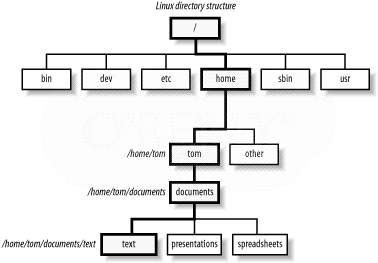

- Upon log in, user is at his/her home directory.
- `tree` command (if installed) displays directory structure.  
  `tree -L levels` display levels directories deep.

  ```bash
  # display only directories in levels 1, 2 from root directory
  tree -d -L 2 /
  ```

  ```
  /
  ├── bin -> usr/bin
  ├── boot
  │   ├── efi
  │   ├── grub
  │   └── grub2
  ├── dev
  │   ├── block
  │   ├── bsg
  │   ├── char
  │   ├── cpu
  │   ├── disk
  │   ├── fd -> /proc/self/fd
  │   ├── hugepages
  │   ├── input
  │   ├── mapper
  │   ├── mqueue
  │   ├── net
  │   ├── pts
  │   ├── raw
  │   ├── shm
  │   ├── snd
  │   └── vfio
  ├── etc
  │   ├── acpi
  │   ├── alternatives
  │   ├── audisp
  │   ├── audit
  │   ├── bash_completion.d
  │   ├── binfmt.d
  │   ├── chkconfig.d
  │   ├── cron.d
  │   ├── cron.daily
  │   ├── cron.hourly
  │   ├── cron.monthly
  │   ├── cron.weekly
  │   ├── cups
  │   ├── dbus-1
  │   ├── dconf
  │   ├── default
  ```

  [output cut: 350 more lines]

  ```
      ├── kerberos
      ├── lib
      ├── local
      ├── lock -> ../run/lock
      ├── log
      ├── mail -> spool/mail
      ├── nis
      ├── opt
      ├── preserve
      ├── run -> ../run
      ├── spool
      ├── tmp
      └── yp

  402 directories
  ```

## Move around the file system

- `pwd` prints absolute path to the current working directory:

  ```bash
  pwd
  ```

  ```
  /home/huazhou/ucla-biostat203b-2020winter.github.io/slides/02-linux
  ```

- `ls` lists contents of a directory:

  ```bash
  ls
  ```

  ```
  autoSim.R
  Emacs_Reference_Card.pdf
  IDRE_Winter_2019_Workshops.pdf
  key_authentication_1.png
  key_authentication_2.png
  linux_directory_structure.png
  linux_filepermission_oct.png
  linux_filepermission.png
  linux.html
  linux.Rmd
  meanEst.R
  Richard_Stallman_2013.png
  runSim.R
  screenshot_top.png
  Vi_Cheat_Sheet.pdf
  ```

- `ls -l` lists detailed contents of a directory:

  ```bash
  ls -l
  ```

  ```
  total 4316
  -rw-r--r--. 1 huazhou huazhou     258 Jan 15 00:59 autoSim.R
  -rw-rw-r--. 1 huazhou huazhou  110345 Jan  9 23:24 Emacs_Reference_Card.pdf
  -rw-rw-r--. 1 huazhou huazhou  157353 Jan  9 23:24 IDRE_Winter_2019_Workshops.pdf
  -rw-rw-r--. 1 huazhou huazhou  321281 Jan  9 23:24 key_authentication_1.png
  -rw-rw-r--. 1 huazhou huazhou   96119 Jan  9 23:24 key_authentication_2.png
  -rw-rw-r--. 1 huazhou huazhou   11662 Jan  9 23:24 linux_directory_structure.png
  -rw-rw-r--. 1 huazhou huazhou   42472 Jan  9 23:24 linux_filepermission_oct.png
  -rw-rw-r--. 1 huazhou huazhou  102188 Jan  9 23:24 linux_filepermission.png
  -rw-rw-r--. 1 huazhou huazhou 2713904 Jan 14 19:31 linux.html
  -rw-r--r--. 1 huazhou huazhou   22773 Jan 14 19:26 linux.Rmd
  -rw-rw-r--. 1 huazhou huazhou     381 Jan  9 23:24 meanEst.R
  -rw-rw-r--. 1 huazhou huazhou  141962 Jan  9 23:24 Richard_Stallman_2013.png
  -rw-rw-r--. 1 huazhou huazhou     498 Jan  9 23:24 runSim.R
  -rw-rw-r--. 1 huazhou huazhou  469335 Jan  9 23:24 screenshot_top.png
  -rw-rw-r--. 1 huazhou huazhou  199492 Jan  9 23:24 Vi_Cheat_Sheet.pdf
  ```

- `ls -al` lists all contents of a directory, including those start with `.` (hidden folders):

  ```bash
  ls -al
  ```

  ```
  total 4324
  drwxrwxr-x. 2 huazhou huazhou    4096 Jan 15 01:01 .
  drwxrwxr-x. 7 huazhou huazhou     117 Jan 14 17:01 ..
  -rw-r--r--. 1 huazhou huazhou     258 Jan 15 00:59 autoSim.R
  -rw-rw-r--. 1 huazhou huazhou  110345 Jan  9 23:24 Emacs_Reference_Card.pdf
  -rw-rw-r--. 1 huazhou huazhou  157353 Jan  9 23:24 IDRE_Winter_2019_Workshops.pdf
  -rw-rw-r--. 1 huazhou huazhou  321281 Jan  9 23:24 key_authentication_1.png
  -rw-rw-r--. 1 huazhou huazhou   96119 Jan  9 23:24 key_authentication_2.png
  -rw-rw-r--. 1 huazhou huazhou   11662 Jan  9 23:24 linux_directory_structure.png
  -rw-rw-r--. 1 huazhou huazhou   42472 Jan  9 23:24 linux_filepermission_oct.png
  -rw-rw-r--. 1 huazhou huazhou  102188 Jan  9 23:24 linux_filepermission.png
  -rw-rw-r--. 1 huazhou huazhou 2713904 Jan 14 19:31 linux.html
  -rw-r--r--. 1 huazhou huazhou   22773 Jan 14 19:26 linux.Rmd
  -rw-rw-r--. 1 huazhou huazhou     381 Jan  9 23:24 meanEst.R
  -rw-r--r--. 1 huazhou huazhou    4096 Jan 14 19:31 .RData
  -rw-rw-r--. 1 huazhou huazhou  141962 Jan  9 23:24 Richard_Stallman_2013.png
  -rw-rw-r--. 1 huazhou huazhou     498 Jan  9 23:24 runSim.R
  -rw-rw-r--. 1 huazhou huazhou  469335 Jan  9 23:24 screenshot_top.png
  -rw-rw-r--. 1 huazhou huazhou  199492 Jan  9 23:24 Vi_Cheat_Sheet.pdf
  ```

- `..` denotes the parent of current working directory.
- `.` denotes the current working directory.
- `~` denotes user’s home directory.
- `/` denotes the root directory.
- `cd ..` changes to parent directory.
- `cd` or `cd ~` changes to home directory.
- `cd /` changes to root directory.

## File permissions

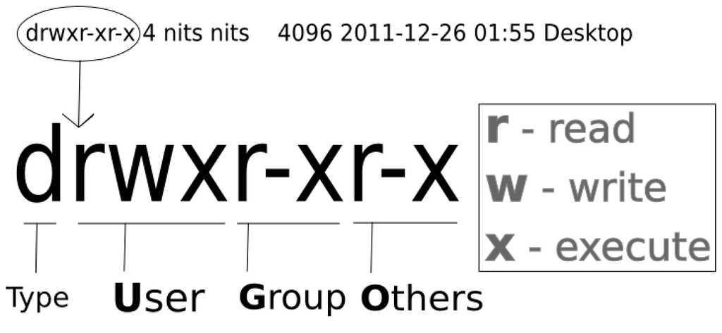

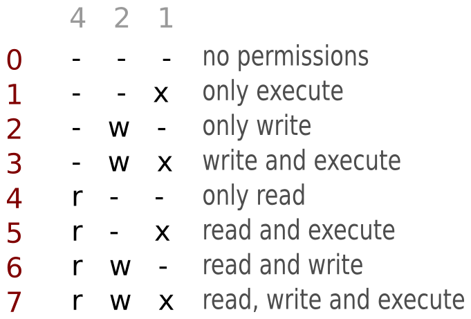

- `chmod g+x file` makes a file executable to group members.
- `chmod 751 file` sets permission `rwxr-x--x` to a file.
- `groups userid` shows which group(s) a user belongs to:

  ```bash
  groups huazhou
  ```

  ```
  huazhou : huazhou adm wheel video
  ```

## Manipulate files and directories

- `cp` copies file to a new location.
- `mv` moves file to a new location.
- `touch` creates a text file; if file already exists, it’s left unchanged.
- `rm` deletes a file.
- `mkdir` creates a new directory.
- `rmdir` deletes an *empty* directory.
- `rm -rf` deletes a directory and all contents in that directory (be cautious using the `-f` option …).

## Find files

- `locate` locates a file by name (need `mlocate` program installed):

  ```bash
  locate linux.Rmd
  ```

  ```
  /home/huazhou/ucla-biostat203b-2020winter.github.io/slides/02-linux/linux.Rmd
  ```

- `find` is similar to `locate` but has more functionalities, e.g., select files by age, size, permissions, …. , and is ubiquitous.

  ```bash
  find linux.Rmd
  ```

  ```
  linux.Rmd
  ```

  ```bash
  find /home/huazhou -name linux.Rmd
  ```

  ```
  /home/huazhou/ucla-biostat203b-2020winter.github.io/slides/02-linux/linux.Rmd
  ```

- `which` locates a program (executable file):

  ```bash
  which R
  ```

  ```
  /usr/bin/R
  ```

## Wildcard characters

| Wildcard | Matches |
| --- | --- |
| `?` | any single character |
| `*` | any character 0 or more times |
| `+` | one or more preceding pattern |
| `^` | beginning of the line |
| `$` | end of the line |
| `[set]` | any character in set |
| `[!set]` | any character not in set |
| `[a-z]` | any lowercase letter |
| `[0-9]` | any number (same as `[0123456789]`) |

- ```bash
  # all png files in current folder
  ls -l *.png
  ```

  ```
  -rw-rw-r--. 1 huazhou huazhou 321281 Jan  9 23:24 key_authentication_1.png
  -rw-rw-r--. 1 huazhou huazhou  96119 Jan  9 23:24 key_authentication_2.png
  -rw-rw-r--. 1 huazhou huazhou  11662 Jan  9 23:24 linux_directory_structure.png
  -rw-rw-r--. 1 huazhou huazhou  42472 Jan  9 23:24 linux_filepermission_oct.png
  -rw-rw-r--. 1 huazhou huazhou 102188 Jan  9 23:24 linux_filepermission.png
  -rw-rw-r--. 1 huazhou huazhou 141962 Jan  9 23:24 Richard_Stallman_2013.png
  -rw-rw-r--. 1 huazhou huazhou 469335 Jan  9 23:24 screenshot_top.png
  ```

## Regular expression

- Wildcards are examples of *regular expressions*.
- Regular expressions are a powerful tool to efficiently sift through large amounts of text: record linking, data cleaning, scraping data from website or other data-feed.
- Google `regular expressions` to learn.

# Work with text files

## View/peek text files

- `cat` prints the contents of a file:

  ```bash
  cat runSim.R
  ```

  ```
  ## parsing command arguments
  for (arg in commandArgs(TRUE)) {
    eval(parse(text=arg))
  }

  ## check if a given integer is prime
  isPrime = function(n) {
    if (n <= 3) {
      return (TRUE)
    }
    if (any((n %% 2:floor(sqrt(n))) == 0)) {
      return (FALSE)
    }
    return (TRUE)
  }

  ## estimate mean only using observation with prime indices
  estMeanPrimes = function (x) {
    n = length(x)
    ind = sapply(1:n, isPrime)
    return (mean(x[ind]))
  }

  # simulate data
  x = rnorm(n)

  # estimate mean
  estMeanPrimes(x)
  ```

- `head` prints the first 10 lines of a file:

  ```bash
  head runSim.R
  ```

  ```
  ## parsing command arguments
  for (arg in commandArgs(TRUE)) {
    eval(parse(text=arg))
  }

  ## check if a given integer is prime
  isPrime = function(n) {
    if (n <= 3) {
      return (TRUE)
    }
  ```

  `head -l` prints the first $l$ lines of a file:

  ```bash
  head -15 runSim.R
  ```

  ```
  ## parsing command arguments
  for (arg in commandArgs(TRUE)) {
    eval(parse(text=arg))
  }

  ## check if a given integer is prime
  isPrime = function(n) {
    if (n <= 3) {
      return (TRUE)
    }
    if (any((n %% 2:floor(sqrt(n))) == 0)) {
      return (FALSE)
    }
    return (TRUE)
  }
  ```

- `tail` prints the last 10 lines of a file:

  ```bash
  tail runSim.R
  ```

  ```
    n = length(x)
    ind = sapply(1:n, isPrime)
    return (mean(x[ind]))
  }

  # simulate data
  x = rnorm(n)

  # estimate mean
  estMeanPrimes(x)
  ```

  `tail -l` prints the last $l$ lines of a file:

  ```bash
  tail -15 runSim.R
  ```

  ```
    return (TRUE)
  }

  ## estimate mean only using observation with prime indices
  estMeanPrimes = function (x) {
    n = length(x)
    ind = sapply(1:n, isPrime)
    return (mean(x[ind]))
  }

  # simulate data
  x = rnorm(n)

  # estimate mean
  estMeanPrimes(x)
  ```

- Questions:
  - How to see the 11th line of the file and nothing else?
  - What about the 11th to the last line?

## Piping and redirection

- `|` sends output from one command as input of another command.
- `>` directs output from one command to a file.
- `>>` appends output from one command to a file.
- `<` reads input from a file.
- Combinations of shell commands (`grep`, `sed`, `awk`, …), piping and redirection, and regular expressions allow us pre-process and reformat huge text files efficiently.
- See HW1.

## `less` is more; `more` is less

- `more` browses a text file screen by screen (only downwards). Scroll down one page (paging) by pressing the spacebar; exit by pressing the `q` key.
- `less` is also a pager, but has more functionalities, e.g., scroll upwards and downwards through the input.
- `less` doesn’t need to read the whole file, i.e., it loads files faster than `more`.

## `grep`

`grep` prints lines that match an expression:

- Show lines that contain string `CentOS`:

  ```bash
  # quotes not necessary if not a regular expression
  grep 'CentOS' linux.Rmd
  ```

  ```
  - RHEL/CentOS is popular on servers.
  - The teaching server for this class runs CentOS 7.
  - Show lines that contain string `CentOS`:
      grep 'CentOS' linux.Rmd
      grep 'CentOS' *.Rmd
      grep -n 'CentOS' linux.Rmd
  - Replace `CentOS` by `RHEL` in a text file:
      sed 's/CentOS/RHEL/' linux.Rmd | grep RHEL
  ```

- Search multiple text files:

  ```bash
  grep 'CentOS' *.Rmd
  ```

  ```
  - RHEL/CentOS is popular on servers.
  - The teaching server for this class runs CentOS 7.
  - Show lines that contain string `CentOS`:
      grep 'CentOS' linux.Rmd
      grep 'CentOS' *.Rmd
      grep -n 'CentOS' linux.Rmd
  - Replace `CentOS` by `RHEL` in a text file:
      sed 's/CentOS/RHEL/' linux.Rmd | grep RHEL
  ```

- Show matching line numbers:

  ```bash
  grep -n 'CentOS' linux.Rmd
  ```

  ```
  34:- RHEL/CentOS is popular on servers.
  36:- The teaching server for this class runs CentOS 7.
  323:- Show lines that contain string `CentOS`:
  326:    grep 'CentOS' linux.Rmd
  331:    grep 'CentOS' *.Rmd
  336:    grep -n 'CentOS' linux.Rmd
  353:- Replace `CentOS` by `RHEL` in a text file:
  355:    sed 's/CentOS/RHEL/' linux.Rmd | grep RHEL
  ```

- Find all files in current directory with `.png` extension:

  ```bash
  ls | grep '.png$'
  ```

  ```
  key_authentication_1.png
  key_authentication_2.png
  linux_directory_structure.png
  linux_filepermission_oct.png
  linux_filepermission.png
  Richard_Stallman_2013.png
  screenshot_top.png
  ```

- Find all directories in the current directory:

  ```bash
  ls -al | grep '^d'
  ```

  ```
  drwxrwxr-x. 2 huazhou huazhou    4096 Jan 15 01:01 .
  drwxrwxr-x. 7 huazhou huazhou     117 Jan 14 17:01 ..
  ```

## `sed`

- `sed` is a stream editor.
- Replace `CentOS` by `RHEL` in a text file:

  ```bash
  sed 's/CentOS/RHEL/' linux.Rmd | grep RHEL
  ```

  ```
  - RHEL/RHEL is popular on servers.
  - The teaching server for this class runs RHEL 7.
  - Show lines that contain string `RHEL`:
      grep 'RHEL' linux.Rmd
      grep 'RHEL' *.Rmd
      grep -n 'RHEL' linux.Rmd
  - Replace `RHEL` by `RHEL` in a text file:
      sed 's/RHEL/RHEL/' linux.Rmd | grep RHEL
  ```

## `awk`

- `awk` is a filter and report writer.
- First let’s display first lines of the file `/etc/passwd`:

  ```bash
  head /etc/passwd
  ```

  ```
  root:x:0:0:root:/root:/bin/bash
  bin:x:1:1:bin:/bin:/sbin/nologin
  daemon:x:2:2:daemon:/sbin:/sbin/nologin
  adm:x:3:4:adm:/var/adm:/sbin/nologin
  lp:x:4:7:lp:/var/spool/lpd:/sbin/nologin
  sync:x:5:0:sync:/sbin:/bin/sync
  shutdown:x:6:0:shutdown:/sbin:/sbin/shutdown
  halt:x:7:0:halt:/sbin:/sbin/halt
  mail:x:8:12:mail:/var/spool/mail:/sbin/nologin
  operator:x:11:0:operator:/root:/sbin/nologin
  ```

  Each line contains fields (1) user name, (2) password, (3) user ID, (4) group ID, (5) user ID info, (6) home directory, and (7) command shell, spearated by `:`.
- Print sorted list of login names:

  ```bash
  awk -F: '{ print $1 }' /etc/passwd | sort | head -10
  ```

  ```
  203bdemo
  adm
  amisheth26
  andyliugraduateschool
  bin
  brendonchau
  brett.young
  bursontung97
  char.flournoy
  chenyu1997
  ```

- Print number of lines in a file, as `NR` stands for Number of Rows:

  ```bash
  awk 'END { print NR }' /etc/passwd
  ```

  ```
  69
  ```

  or

  ```bash
  wc -l /etc/passwd
  ```

  ```
  69 /etc/passwd
  ```

  or (not displaying file name)

  ```bash
  wc -l < /etc/passwd
  ```

  ```
  69
  ```

- Print login names with UID in range `1000-1035`:

  ```bash
  awk -F: '{if ($3 >= 1000 && $3 <= 1035) print}' /etc/passwd
  ```

  ```
  huazhou:x:1000:1001::/home/huazhou:/bin/bash
  juhkim111:x:1001:1003::/home/juhkim111:/bin/bash
  raguilar2:x:1002:1004::/home/raguilar2:/bin/bash
  elalb:x:1003:1005::/home/elalb:/bin/bash
  sdalmia:x:1004:1006::/home/sdalmia:/bin/bash
  gdewey:x:1005:1007::/home/gdewey:/bin/bash
  mfdong12:x:1006:1008::/home/mfdong12:/bin/bash
  farboodi:x:1007:1009::/home/farboodi:/bin/bash
  mfaulis17:x:1008:1010::/home/mfaulis17:/bin/bash
  char.flournoy:x:1009:1011::/home/char.flournoy:/bin/bash
  willgertsch:x:1010:1012::/home/willgertsch:/bin/bash
  ynguo94:x:1011:1013::/home/ynguo94:/bin/bash
  ghancock:x:1012:1014::/home/ghancock:/bin/bash
  krh005:x:1013:1015::/home/krh005:/bin/bash
  yilanh19:x:1014:1016::/home/yilanh19:/bin/bash
  nslly19:x:1015:1017::/home/nslly19:/bin/bash
  tonylim:x:1016:1018::/home/tonylim:/bin/bash
  andyliugraduateschool:x:1017:1019::/home/andyliugraduateschool:/bin/bash
  lnliuxue:x:1018:1020::/home/lnliuxue:/bin/bash
  y9lyu:x:1019:1021::/home/y9lyu:/bin/bash
  lillynhan:x:1020:1022::/home/lillynhan:/bin/bash
  joodeh:x:1021:1023::/home/joodeh:/bin/bash
  wenlanpan:x:1022:1024::/home/wenlanpan:/bin/bash
  stpraser18:x:1023:1025::/home/stpraser18:/bin/bash
  qiqi0610:x:1024:1026::/home/qiqi0610:/bin/bash
  Johnrandazzo1996:x:1025:1027::/home/Johnrandazzo1996:/bin/bash
  amisheth26:x:1026:1028::/home/amisheth26:/bin/bash
  ranjana.n.w:x:1027:1029::/home/ranjana.n.w:/bin/bash
  naomixu:x:1028:1030::/home/naomixu:/bin/bash
  xurui1996:x:1029:1031::/home/xurui1996:/bin/bash
  brett.young:x:1030:1032::/home/brett.young:/bin/bash
  hanyanyuan:x:1031:1033::/home/hanyanyuan:/bin/bash
  203bdemo:x:1032:1034::/home/203bdemo:/bin/bash
  dalekim25:x:1033:1035::/home/dalekim25:/bin/bash
  chenyu1997:x:1034:1036::/home/chenyu1997:/bin/bash
  hk_lian:x:1035:1037::/home/hk_lian:/bin/bash
  ```

- Print login names and log-in shells in comma-seperated format:

  ```bash
  awk -F: '{OFS = ","} {print $1, $7}' /etc/passwd
  ```

  ```
  root,/bin/bash
  bin,/sbin/nologin
  daemon,/sbin/nologin
  adm,/sbin/nologin
  lp,/sbin/nologin
  sync,/bin/sync
  shutdown,/sbin/shutdown
  halt,/sbin/halt
  mail,/sbin/nologin
  operator,/sbin/nologin
  games,/sbin/nologin
  ftp,/sbin/nologin
  nobody,/sbin/nologin
  systemd-network,/sbin/nologin
  dbus,/sbin/nologin
  polkitd,/sbin/nologin
  ntp,/sbin/nologin
  sshd,/sbin/nologin
  postfix,/sbin/nologin
  chrony,/sbin/nologin
  huazhou,/bin/bash
  tss,/sbin/nologin
  rstudio-server,/bin/bash
  shiny,/bin/sh
  mongod,/bin/false
  saslauth,/sbin/nologin
  juhkim111,/bin/bash
  raguilar2,/bin/bash
  elalb,/bin/bash
  sdalmia,/bin/bash
  gdewey,/bin/bash
  mfdong12,/bin/bash
  farboodi,/bin/bash
  mfaulis17,/bin/bash
  char.flournoy,/bin/bash
  willgertsch,/bin/bash
  ynguo94,/bin/bash
  ghancock,/bin/bash
  krh005,/bin/bash
  yilanh19,/bin/bash
  ```

  [output cut: 14 more lines]

  ```
  xurui1996,/bin/bash
  brett.young,/bin/bash
  hanyanyuan,/bin/bash
  203bdemo,/bin/bash
  dalekim25,/bin/bash
  chenyu1997,/bin/bash
  hk_lian,/bin/bash
  srishtimajumdar,/bin/bash
  bursontung97,/bin/bash
  jaketompkins97,/bin/bash
  fredericy19,/bin/bash
  brendonchau,/bin/bash
  jshamsho,/bin/bash
  tagibson,/bin/bash
  postgres,/bin/bash
  ```

- Print login names and indicate those with UID>1000 as `vip`:

  ```bash
  awk -F: -v status="" '{OFS = ","}
  {if ($3 >= 1000) status="vip"; else status="regular"}
  {print $1, status}' /etc/passwd
  ```

  ```
  root,regular
  bin,regular
  daemon,regular
  adm,regular
  lp,regular
  sync,regular
  shutdown,regular
  halt,regular
  mail,regular
  operator,regular
  games,regular
  ftp,regular
  nobody,regular
  systemd-network,regular
  dbus,regular
  polkitd,regular
  ntp,regular
  sshd,regular
  postfix,regular
  chrony,regular
  huazhou,vip
  tss,regular
  rstudio-server,regular
  shiny,regular
  mongod,regular
  saslauth,regular
  juhkim111,vip
  raguilar2,vip
  elalb,vip
  sdalmia,vip
  gdewey,vip
  mfdong12,vip
  farboodi,vip
  mfaulis17,vip
  char.flournoy,vip
  willgertsch,vip
  ynguo94,vip
  ghancock,vip
  krh005,vip
  yilanh19,vip
  ```

  [output cut: 14 more lines]

  ```
  xurui1996,vip
  brett.young,vip
  hanyanyuan,vip
  203bdemo,vip
  dalekim25,vip
  chenyu1997,vip
  hk_lian,vip
  srishtimajumdar,vip
  bursontung97,vip
  jaketompkins97,vip
  fredericy19,vip
  brendonchau,vip
  jshamsho,vip
  tagibson,vip
  postgres,regular
  ```

## Text editors

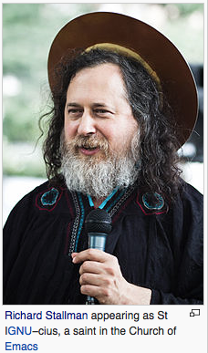

Source: [Editor War](http://en.wikipedia.org/wiki/Editor_war) on Wikipedia.

## Emacs

- `Emacs` is a powerful text editor with extensive support for many languages including `R`, $\LaTeX$, `python`, and `C/C++`; however it’s *not* installed by default on many Linux distributions.
- Basic survival commands:
  - `emacs filename` to open a file with emacs.
  - `CTRL-x CTRL-f` to open an existing or new file.
  - `CTRL-x CTRX-s` to save.
  - `CTRL-x CTRL-w` to save as.
  - `CTRL-x CTRL-c` to quit.
- Google `emacs cheatsheet`

[figure not shown]

`C-<key>` means hold the `control` key, and press `<key>`.  
`M-<key>` means press the `Esc` key once, and press `<key>`.

## Vi

- `Vi` is ubiquitous (POSIX standard). Learn at least its basics; otherwise you can edit nothing on some clusters.
- Basic survival commands:
  - `vi filename` to start editing a file.
  - `vi` is a *modal* editor: *insert* mode and *normal* mode. Pressing `i` switches from the normal mode to insert mode. Pressing `ESC` switches from the insert mode to normal mode.
  - `:x<Return>` quits `vi` and saves changes.
  - `:q!<Return>` quits vi without saving latest changes.
  - `:w<Return>` saves changes.
  - `:wq<Return>` quits `vi` and saves changes.
- Google `vi cheatsheet`

[figure not shown]

## IDE (Integrated Development Environment)

- Statisticians write a lot of code. Critical to adopt a good IDE that goes beyond code editing: syntax highlighting, executing code within editor, debugging, profiling, version control, etc.
- R Studio, Eclipse, Emacs, Matlab, Visual Studio, etc.

# Processes

## Cancel a non-responding program

- Press `Ctrl+C` to cancel a non-responding or long-running program.

## Processes

- OS runs processes on behalf of user.
- Each process has Process ID (PID), Username (UID), Parent process ID (PPID), Time and data process started (STIME), time running (TIME), etc.

  ```bash
  ps
  ```

  ```
    PID TTY          TIME CMD
  19455 ?        00:00:01 rsession
  19529 ?        00:00:00 R
  19644 ?        00:00:00 sh
  19645 ?        00:00:00 ps
  ```

- All current running processes:

  ```bash
  ps -eaf
  ```

  ```
  UID        PID  PPID  C STIME TTY          TIME CMD
  root         1     0  0 Jan09 ?        00:00:24 /usr/lib/systemd/systemd --switched-root --system --deserialize 22
  root         2     0  0 Jan09 ?        00:00:00 [kthreadd]
  root         4     2  0 Jan09 ?        00:00:00 [kworker/0:0H]
  root         6     2  0 Jan09 ?        00:00:00 [ksoftirqd/0]
  root         7     2  0 Jan09 ?        00:00:00 [migration/0]
  root         8     2  0 Jan09 ?        00:00:00 [rcu_bh]
  root         9     2  0 Jan09 ?        00:01:02 [rcu_sched]
  root        10     2  0 Jan09 ?        00:00:00 [lru-add-drain]
  root        11     2  0 Jan09 ?        00:00:02 [watchdog/0]
  root        12     2  0 Jan09 ?        00:00:01 [watchdog/1]
  root        13     2  0 Jan09 ?        00:00:00 [migration/1]
  root        14     2  0 Jan09 ?        00:00:00 [ksoftirqd/1]
  root        16     2  0 Jan09 ?        00:00:00 [kworker/1:0H]
  root        17     2  0 Jan09 ?        00:00:01 [watchdog/2]
  root        18     2  0 Jan09 ?        00:00:00 [migration/2]
  root        19     2  0 Jan09 ?        00:00:01 [ksoftirqd/2]
  root        21     2  0 Jan09 ?        00:00:00 [kworker/2:0H]
  root        22     2  0 Jan09 ?        00:00:01 [watchdog/3]
  root        23     2  0 Jan09 ?        00:00:00 [migration/3]
  root        24     2  0 Jan09 ?        00:00:01 [ksoftirqd/3]
  root        26     2  0 Jan09 ?        00:00:00 [kworker/3:0H]
  root        28     2  0 Jan09 ?        00:00:00 [kdevtmpfs]
  root        29     2  0 Jan09 ?        00:00:00 [netns]
  root        30     2  0 Jan09 ?        00:00:00 [khungtaskd]
  root        31     2  0 Jan09 ?        00:00:00 [writeback]
  root        32     2  0 Jan09 ?        00:00:00 [kintegrityd]
  root        33     2  0 Jan09 ?        00:00:00 [bioset]
  root        34     2  0 Jan09 ?        00:00:00 [bioset]
  root        35     2  0 Jan09 ?        00:00:00 [bioset]
  root        36     2  0 Jan09 ?        00:00:00 [kblockd]
  root        37     2  0 Jan09 ?        00:00:00 [md]
  root        38     2  0 Jan09 ?        00:00:00 [edac-poller]
  root        39     2  0 Jan09 ?        00:00:00 [watchdogd]
  root        46     2  0 Jan09 ?        00:00:00 [kswapd0]
  root        47     2  0 Jan09 ?        00:00:00 [ksmd]
  root        48     2  0 Jan09 ?        00:00:02 [khugepaged]
  root        49     2  0 Jan09 ?        00:00:00 [crypto]
  root        57     2  0 Jan09 ?        00:00:00 [kthrotld]
  root        59     2  0 Jan09 ?        00:00:00 [kmpath_rdacd]
  ```

  [output cut: 67 more lines]

  ```
  qiqi0610 15495 15491  0 04:51 ?        00:00:00 sshd: qiqi0610@pts/2
  qiqi0610 15496 15495  0 04:51 pts/2    00:00:00 -bash
  root     15783     2  0 04:54 ?        00:00:00 [kworker/3:0]
  root     16214     2  0 05:00 ?        00:00:00 [kworker/0:1]
  root     17791     2  0 05:21 ?        00:00:00 [kworker/3:1]
  root     18456     2  0 05:31 ?        00:00:00 [kworker/1:2]
  root     18848     2  0 05:37 ?        00:00:00 [kworker/1:0]
  root     19171     2  0 05:42 ?        00:00:00 [kworker/1:1]
  root     19174     2  0 05:42 ?        00:00:00 [kworker/0:2]
  huazhou  19455  1441  7 05:47 ?        00:00:01 /usr/lib/rstudio-server/bin/rsession -u huazhou --launcher-token BB375147
  huazhou  19529 19455 48 05:47 ?        00:00:00 /usr/lib64/R/bin/exec/R --slave --no-save --no-restore -e rmarkdown::render('/home/huazhou/ucla-biostat203b-2020winter.github.io/slides/02-linux/linux.Rmd',~+~~+~encoding~+~=~+~'UTF-8');
  huazhou  19646 19529  0 05:47 ?        00:00:00 sh -c 'bash'  -c 'ps -eaf' 2>&1
  huazhou  19647 19646  0 05:47 ?        00:00:00 ps -eaf
  root     24201     2  0 Jan14 ?        00:00:01 [kworker/u8:1]
  root     31010     2  0 00:59 ?        00:00:00 [kworker/2:0]
  ```

- All Python processes:

  ```bash
  ps -eaf | grep python
  ```

  ```
  root       944     1  0 Jan09 ?        00:00:01 /usr/bin/python2 -Es /usr/sbin/firewalld --nofork --nopid
  root      1365     1  0 Jan09 ?        00:00:51 /usr/bin/python2 -Es /usr/sbin/tuned -l -P
  root      1628     1  0 Jan09 ?        00:00:24 /usr/bin/python /usr/bin/google_network_daemon
  root      1633     1  0 Jan09 ?        00:00:46 /usr/bin/python /usr/bin/google_accounts_daemon
  root      1635     1  0 Jan09 ?        00:00:10 /usr/bin/python /usr/bin/google_clock_skew_daemon
  root     11037 11033  0 03:45 ?        00:00:00 /usr/bin/python -tt /usr/sbin/yum-cron
  huazhou  19648 19529  0 05:47 ?        00:00:00 sh -c 'bash'  -c 'ps -eaf | grep python' 2>&1
  huazhou  19649 19648  0 05:47 ?        00:00:00 bash -c ps -eaf | grep python
  huazhou  19651 19649  0 05:47 ?        00:00:00 grep python
  ```

- Process with PID=1:

  ```bash
  ps -fp 1
  ```

  ```
  UID        PID  PPID  C STIME TTY          TIME CMD
  root         1     0  0 Jan09 ?        00:00:24 /usr/lib/systemd/systemd --switched-root --system --deserialize 22
  ```

- All processes owned by a user:

  ```bash
  ps -fu huazhou
  ```

  ```
  UID        PID  PPID  C STIME TTY          TIME CMD
  huazhou  19455  1441  7 05:47 ?        00:00:01 /usr/lib/rstudio-server/bin/rsession -u huazhou --launcher-token BB375147
  huazhou  19529 19455 49 05:47 ?        00:00:00 /usr/lib64/R/bin/exec/R --slave --no-save --no-restore -e rmarkdown::render('/home/huazhou/ucla-biostat203b-2020winter.github.io/slides/02-linux/linux.Rmd',~+~~+~encoding~+~=~+~'UTF-8');
  huazhou  19654 19529  0 05:47 ?        00:00:00 sh -c 'bash'  -c 'ps -fu huazhou' 2>&1
  huazhou  19655 19654  0 05:47 ?        00:00:00 ps -fu huazhou
  ```

## Kill processes

- Kill process with PID=1001:

  ```bash
  kill 1001
  ```

- Kill all R processes.

  ```bash
  killall -r R
  ```

## `top`

- `top` prints realtime process information (very useful).

  ```bash
  top
  ```

[figure not shown]

- Exit the `top` program by pressing the `q` key.

# Secure shell (SSH)

## SSH

SSH (secure shell) is the dominant cryptographic network protocol for secure network connection via an insecure network.

- On Linux or Mac ternminal, access the teaching server by

  ```bash
  ssh username@server.ucla-biostat-203b.com
  ```

## Use keys over password

- Key authentication is more secure than password. Most passwords are weak.
- Script or a program may need to systematically SSH into other machines.
- Log into multiple machines using the same key.
- Seamless use of many services: Git, AWS or Google cloud service, parallel computing on multiple hosts, Travis CI (continuous integration) etc.
- Many servers only allow key authentication and do not accept password authentication.

## Key authentication

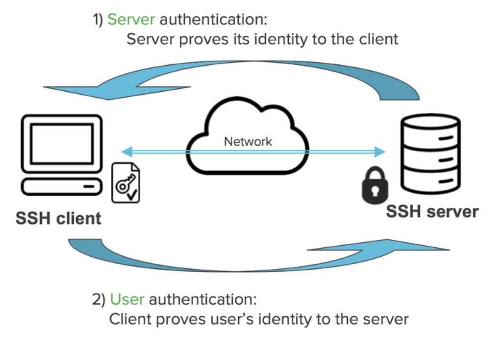

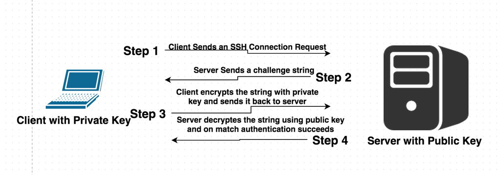

- *Public key*. Put on the machine(s) you want to log in.
- *Private key*. Put on your own computer. Consider this as the actual key in your pocket; never give to others.
- Messages from server to your computer is encrypted with your public key. It can only be decrypted using your private key.
- Messages from your computer to server is signed with your private key (digital signatures) and can be verified by anyone who has your public key (authentication).

## Steps to generate keys

- On Linux, Mac, or Windows Git Bash, to generate a key pair:

  ```bash
  ssh-keygen -t rsa -f ~/.ssh/[KEY_FILENAME] -C [USERNAME]
  ```

  - `[KEY_FILENAME]` is the name that you want to use for your SSH key files. For example, a filename of `id_rsa` generates a private key file named `id_rsa` and a public key file named `id_rsa.pub`.
  - `[USERNAME]` is the user for whom you will apply this SSH key.
  - Use a (optional) paraphrase different form password.
- Set correct permissions on the `.ssh` folder and key files

  ```bash
  chmod 400 ~/.ssh/[KEY_FILENAME]
  ```

- Append the public key to the `~/.ssh/authorized_keys` file of any Linux machine we want to SSH to, e.g.,

  ```bash
  ssh-copy-id -i ~/.ssh/[KEY_FILENAME] [USERNAME]@server.ucla-biostat-203b.com
  ```

- Test your new key.

  ```bash
  ssh -i ~/.ssh/[KEY_FILENAME] [USERNAME]@server.ucla-biostat-203b.com
  ```

- Now you don’t need password each time you connect from your machine to the teaching server.
- If you set paraphrase when generating keys, you’ll be prompted for the paraphrase each time the private key is used. Avoid repeatedly entering the paraphrase by using `ssh-agent` on Linux/Mac or Pagent on Windows.
- Same key pair can be used between any two machines. We don’t need to regenerate keys for each new connection.

## Transfer files between machines

- `scp` securely transfers files between machines using SSH.

  ```bash
  ## copy file from local to remote
  scp [LOCALFILE] [USERNAME]@server.ucla-biostat-203b.com:/[PATH_TO_FOLDER]
  ```

  ```bash
  ## copy file from remote to local
  scp [USERNAME]@server.ucla-biostat-203b.com:/[PATH_TO_FILE] [PATH_TO_LOCAL_FOLDER]
  ```

- `sftp` is FTP via SSH.
- `Globus` is GUI program for securely transferring files between machines. To use Globus you will have to go to https://www.globus.org/ and login through UCLA by selecting your existing organizational login as UCLA. Then you will need to download their Globus Connect Personal software, then set your laptop as an endpoint. Very detailed instructions can be found at https://www.hoffman2.idre.ucla.edu/file-transfer/globus/.
- GUIs for Windows (WinSCP) or Mac (Cyberduck).
- (My preferred way) Use a **version control system** (git, svn, cvs, …) to sync project files between different machines and systems.

## Line breaks in text files

- Windows uses a pair of `CR` and `LF` for line breaks.
- Linux/Unix uses an `LF` character only.
- MacOS X also uses a single `LF` character. But old Mac OS used a single `CR` character for line breaks.
- If transferred in binary mode (bit by bit) between OSs, a text file could look a mess.
- Most transfer programs automatically switch to text mode when transferring text files and perform conversion of line breaks between different OSs; but I used to run into problems using WinSCP. Sometimes you have to tell WinSCP explicitly a text file is being transferred.

# Run R in Linux

## Interactive mode

- Start R in the interactive mode by typing `R` in shell.
- Then run R script by

  ```r
  source("script.R")
  ```

## Batch mode

- Demo script [`meanEst.R`](https://raw.githubusercontent.com/ucla-biostat203b-2020winter/ucla-biostat203b-2020winter.github.io/master/slides/02-linux/meanEst.R) implements an (terrible) estimator of mean
  $${\widehat \mu}_n = \frac{\sum_{i=1}^n x_i 1_{i \text{ is prime}}}{\sum_{i=1}^n 1_{i \text{ is prime}}}.$$

  ```
  ## check if a given integer is prime
  isPrime = function(n) {
    if (n <= 3) {
      return (TRUE)
    }
    if (any((n %% 2:floor(sqrt(n))) == 0)) {
      return (FALSE)
    }
    return (TRUE)
  }

  ## estimate mean only using observation with prime indices
  estMeanPrimes = function (x) {
    n = length(x)
    ind = sapply(1:n, isPrime)
    return (mean(x[ind]))
  }

  print(estMeanPrimes(rnorm(100000)))
  ```

- To run your R code non-interactively aka in batch mode, we have at least two options:

  ```bash
  # default output to meanEst.Rout
  R CMD BATCH meanEst.R
  ```

  or

  ```bash
  # output to stdout
  Rscript meanEst.R
  ```

- Typically automate batch calls using a scripting language, e.g., Python, Perl, and shell script.

## Pass arguments to R scripts

- Specify arguments in `R CMD BATCH`:

  ```bash
  R CMD BATCH '--args mu=1 sig=2 kap=3' script.R
  ```

- Specify arguments in `Rscript`:

  ```bash
  Rscript script.R mu=1 sig=2 kap=3
  ```

- Parse command line arguments using magic formula

  ```r
  for (arg in commandArgs(T)) {
    eval(parse(text=arg))
  }
  ```

  in R script. After calling the above code, all command line arguments will be available in the global namespace.
- To understand the magic formula `commandArgs`, run R by:

  ```bash
  R '--args mu=1 sig=2 kap=3'
  ```

  and then issue commands in R

  ```r
  commandArgs()
  commandArgs(TRUE)
  ```

- Understand the magic formula `parse` and `eval`:

  ```r
  rm(list=ls())
  print(x)
  ```

  ```
  Error in print(x): object 'x' not found
  ```

  ```r
  parse(text="x=3")
  ```

  ```
  expression(x = 3)
  ```

  ```r
  eval(parse(text="x=3"))
  print(x)
  ```

  ```
  [1] 3
  ```

- [`runSim.R`](https://raw.githubusercontent.com/ucla-biostat203b-2020winter/ucla-biostat203b-2020winter.github.io/master/slides/02-linux/runSim.R) has components: (1) **command argument parser**, (2) method implementation, (3) data generator with unspecified parameter `n`, and (4) estimation based on generated data.

```
## parsing command arguments
for (arg in commandArgs(TRUE)) {
  eval(parse(text=arg))
}

## check if a given integer is prime
isPrime = function(n) {
  if (n <= 3) {
    return (TRUE)
  }
  if (any((n %% 2:floor(sqrt(n))) == 0)) {
    return (FALSE)
  }
  return (TRUE)
}

## estimate mean only using observation with prime indices
estMeanPrimes = function (x) {
  n = length(x)
  ind = sapply(1:n, isPrime)
  return (mean(x[ind]))
}

# simulate data
x = rnorm(n)

# estimate mean
estMeanPrimes(x)
```

- Call `runSim.R` with sample size `n=100`:

  ```bash
  R CMD BATCH '--args n=100' runSim.R
  ```

  or

  ```bash
  Rscript runSim.R n=100
  ```

  ```
  [1] 0.1883607
  ```

## Run long jobs

- Many statistical computing tasks take long: simulation, MCMC, etc. When we exit Linux when the job is unfinished, the job is killed.
- `nohup` command in Linux runs program(s) immune to hangups and writes output to `nohup.out` by default. Logging out will *not* kill the process; we can log in later to check status and results.
- `nohup` is POSIX standard thus available on Linux and MacOS.
- Run `runSim.R` in background and writes output to `nohup.out`:

  ```bash
  nohup Rscript runSim.R n=100 &
  ```

  ```
  [1] 0.1704422
  ```

  The `&` at the end of the command instructs Linux to run this command in background, so we gain control of the terminal immediately.

## screen

- `screen` is another popular utility, but not installed by default.
- Typical workflow using `screen`.
  0. Access remote server using `ssh`.
  1. Start jobs in batch mode.
  2. Detach jobs.
  3. Exit from server, wait for jobs to finish.
  4. Access remote server using `ssh`.
  5. Re-attach jobs, check on progress, get results, etc.

## Use R to call R

R in conjuction with `nohup` (or `screen`) can be used to orchestrate a large simulation study.

- It can be more elegant, transparent, and robust to parallelize jobs corresponding to different scenarios (e.g., different generative models) outside of the code used to do statistical computation.
- We consider a simulation study in R but the same approach could be used with code written in Julia, Matlab, Python, etc.
- Python in many ways makes a better *glue*.
- Suppose we have
  - [`runSim.R`](https://raw.githubusercontent.com/ucla-biostat203b-2020winter/ucla-biostat203b-2020winter.github.io/master/slides/02-linux/runSim.R) which runs a simulation based on command line argument `n`.
  - A large collection of `n` values that we want to use in our simulation study.
  - Access to a server with 128 cores.  
    How do to parallelize the job?
- Option 1: manually call `runSim.R` for each setting.
- Option 2 (smarter): automate calls using R and `nohup`.
- Let’s demonstrate using the script autoSim.R

  ```bash
  cat autoSim.R
  ```

  ```
  # autoSim.R

  nVals <- seq(100, 1000, by=100)
  for (n in nVals) {
    oFile <- paste("n", n, ".txt", sep="")
    sysCall <- paste("nohup Rscript runSim.R n=", n, " > ", oFile, sep="")
    system(sysCall, wait = FALSE)
    print(paste("sysCall=", sysCall, sep=""))
  }
  ```

  Note when we call bash command using the `system` function in R, we set optional argument `wait=FALSE` so that jobs can be run parallel.

- ```bash
  Rscript autoSim.R
  ```

  ```
  [1] "sysCall=nohup Rscript runSim.R n=100 > n100.txt"
  [1] "sysCall=nohup Rscript runSim.R n=200 > n200.txt"
  [1] "sysCall=nohup Rscript runSim.R n=300 > n300.txt"
  [1] "sysCall=nohup Rscript runSim.R n=400 > n400.txt"
  [1] "sysCall=nohup Rscript runSim.R n=500 > n500.txt"
  [1] "sysCall=nohup Rscript runSim.R n=600 > n600.txt"
  [1] "sysCall=nohup Rscript runSim.R n=700 > n700.txt"
  [1] "sysCall=nohup Rscript runSim.R n=800 > n800.txt"
  [1] "sysCall=nohup Rscript runSim.R n=900 > n900.txt"
  [1] "sysCall=nohup Rscript runSim.R n=1000 > n1000.txt"
  ```

- Now we just need to write a script to collect results from the output files.
- Later on we learn how to coordinate large scale computation on UCLA Hoffmann2 cluster, using Linux and R scripting.